# UNICEF REPORT

A world growing older

Author

Jeanne Rabreau

Published

April 25, 2025

# Introduction

The global population is experiencing **ageing** at an unprecedented rate. According to the United Nations (2022), 1 in 6 people worldwide will be over 65 by 2050. While ageing is a shared demographic trend, its speed and intensity vary significantly across regions.

The aim of this report is to answer the following key questions:  
1. *Why are some regions ageing faster than others?*  
2. *What are the economic and social impacts of this demographic shift?*  
3. *And above all, how can we deal with it?*

*The key indicator used in this report is the **Old-Age Dependency Ratio (OADR)**, defined as the ratio between the population aged 65 and over and the number of people of working age (15–64).*  
*Data for this analysis was sourced from **UNICEF**.*

## Key highlights

- **Global aging trend:** The old-age dependency ratio (OADR) has been rising steadily since the 1980s, highlighting a global phenomenon of aging populations.
- **Regional disparities:** Significant differences exist between regions, with higher OADRs in Europe and East Asia, and much lower values in Africa.
- **Correlation between wealth and ageing:** A higher GDP per capita is associated with a higher OADR, as wealthier countries experience longer life expectancy and lower birth rates.
- **Demographic and economic challenges:** In developed countries, the decline in the working-age population relative to the elderly population poses major risks to economic growth and the viability of pension systems.

## Global evolution of OADR: a growing challenge

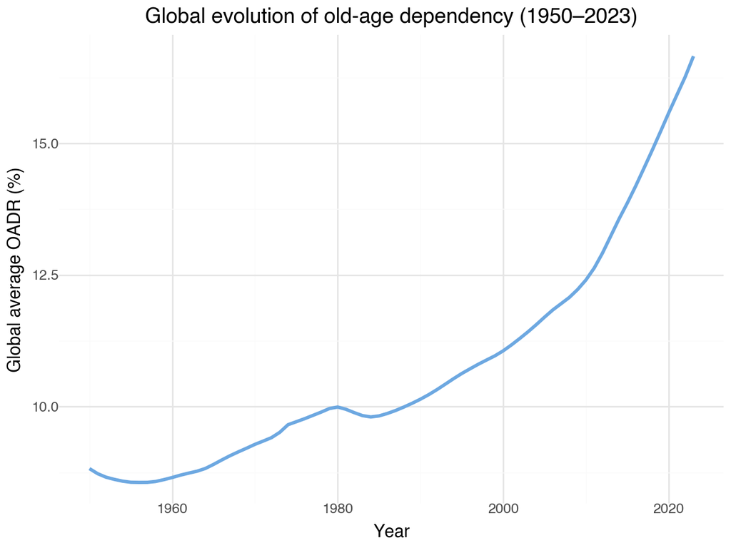

The evolution of the worldwide old-age dependency ratio (OADR) over time shows a clear upward trend since the 1980s. After a period of slow growth between 1950 and 1980, the OADR has accelerated steadily, reaching its highest level in 2023. This confirms **a global phenomenon of aging populations**, which is intensifying over time.

## OADR in the world (2023)

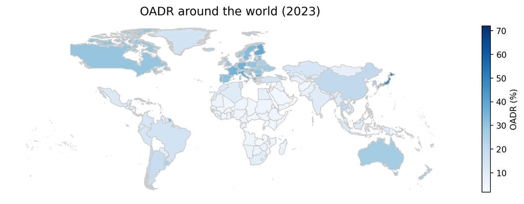

Although the overall trend in ageing is upwards, the map reveals **considerable heterogeneity between the world’s regions**. The OADR is particularly high in Europe, Japan and North America, reflecting a growing proportion of older people relative to the working population. Conversely, many parts of Africa still have low ratios.

## Understanding the roots of demographic ageing

### The wealth-ageing divide: GDP per capita vs OADR

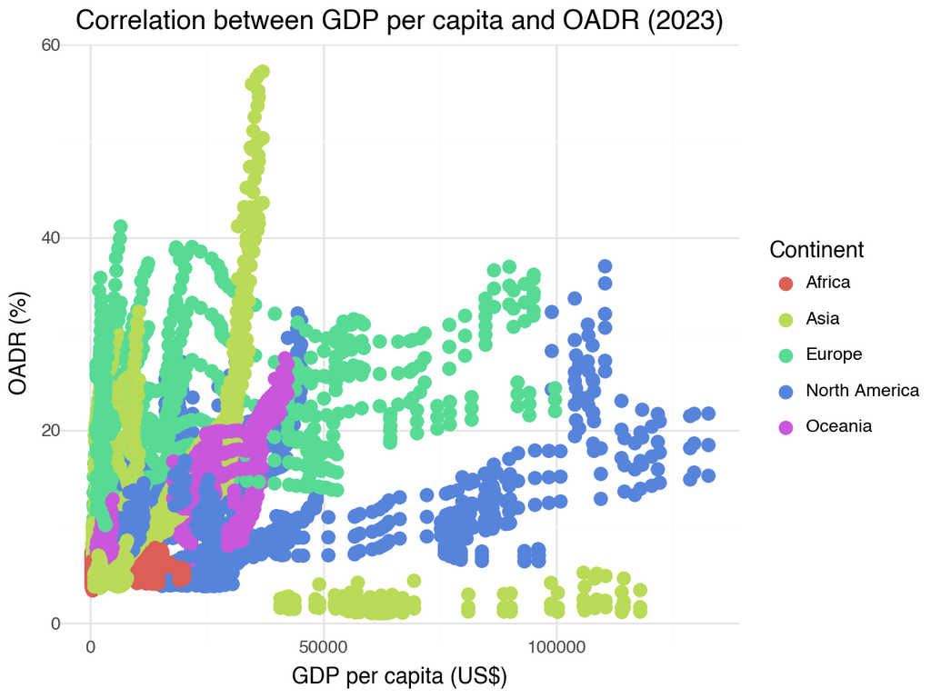

*In Africa, where the OADR remains low, the majority of countries have a GDP per capita of less than 5,000 USD. In Europe, on the other hand, where the OADR is much higher, many countries have a GDP per capita in excess of 30,000 USD, with some even exceeding 50,000 USD.*

### Living longer, ageing more: Life expectancy vs OADR

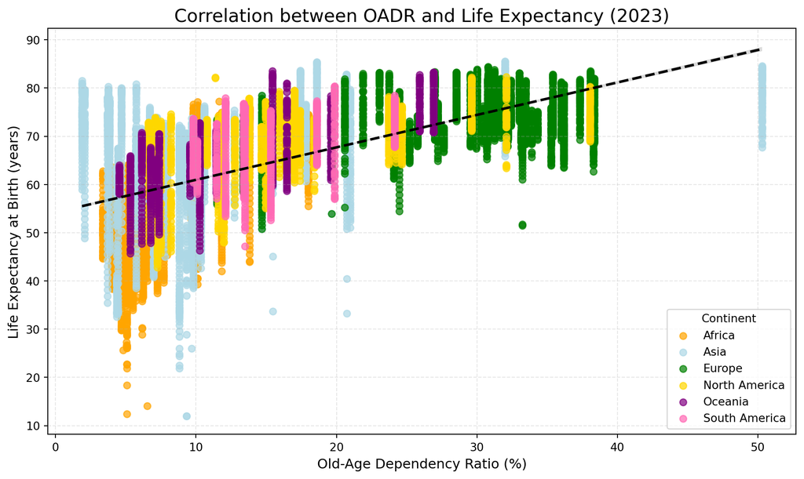

*For instance, Europe, made up largely of developed countries, has significantly higher OADRs than Africa, where life expectancy remains lower and populations are younger overall.*

## The economic and social cost of ageing: declining workforce in Europe

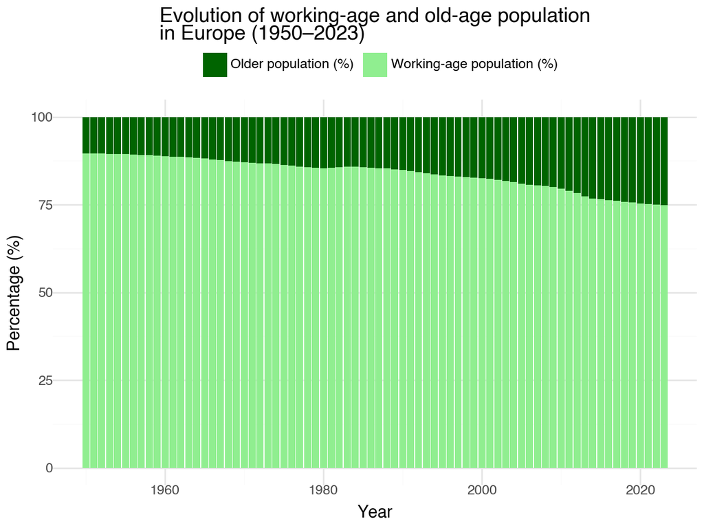

The evolution of the ratio of working-age people to older people in Europe reveals a worrying trend. **The proportion of 15-64 year-olds is gradually declining, while that of the over-65s is increasing, putting further pressure on economic and social systems**. This demographic reversal represents a major challenge for productivity, public finances and the sustainability of pension systems.

# Conclusion and recommendations

The aging of the world’s population, highlighted by the evolution of the OADR, represents **a major challenge** for productivity, the sustainability of pension systems and overall economic equilibrium. The graphs presented underline the scale of this phenomenon, particularly in developed countries, where the proportion of the elderly population continues to grow.

**Fortunately, several solutions exist to mitigate the effects of demographic ageing**:

**1. Encourage migration:** a young workforce from developing countries can compensate for the decline in the number of active workers.

**2. Increase the retirement age:** Adapt public policies to balance the demographic burden.

**3. Stimulate the birth rate:** Support families through birth incentive policies.

**4. Invest in robotization and AI:** Mitigate the shrinking workforce through technological advances.

**Global aging is a challenge, but also an opportunity to adapt our societies for a sustainable future!**

[figure not shown]